# MSDS6306-404 Session3 Assignment

Daniel Davieau

January 25, 2018

### Questions

#### 1. GitHub Cloning (20 points): Using Git, clone the following GitHub repository to your local machine: https://github.com/caesar0301/awesome-public-datasets. In RMarkdown, please show the code (commented out, as it’s not R syntax) that you used to create a new directory, navigate to the appropriate directory, and clone the repository to it. Like actual Git, one command per line, please.

```
#cd Documents/GitHub/DDavieauMSDS6306-404-Doing-Data-Science-FileManagement
#git init DDavieauMSDS6306-404-Doing-Data-Science-FileManagement
#mkdir CloneOfAwesomePublicDatasets
#cd CloneOfAwesomePublicDatasets
#$ git clone https://github.com/caesar0301/awesome-public-datasets
```

#### 2. Data Summary (20 points): From this aforementioned cloned repo, please extract titanic.csv.zip. To be clear, this does not have to be done in Git or command line.

##### a. In R, please read in titanic.csv via either read.table() or read.csv(), assigning it to df. This dataset follows the passengers aboard the Titanic, including their fees paid, rooms rented, and survivorship status.

```r
titanic <- read.csv("CloneOfAwesomePublicDatasets/Datasets/titanic.csv/titanic.csv")
```

##### b. Output the respective count of females and males aboard the Titanic. Plot the frequency of females and males. Be sure to give an accurate title and label the axes.

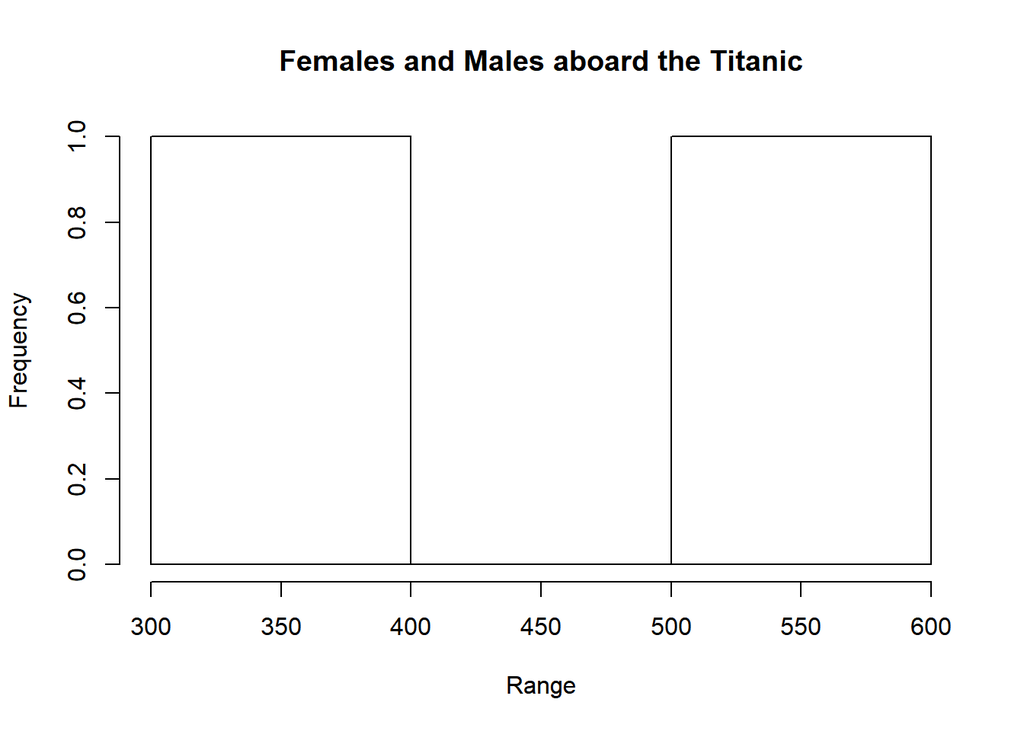

```r
hist(
table(titanic$Sex),
   main = paste("Females and Males aboard the Titanic"),
  xlab = "Range"
   )
```

#####c. Please use one apply function (to review: swirl() modules 11, 12) to output the means of Age, Fare, and Survival. Make sure the output is a real number for all three means.

```r
SurvivedFare<-titanic[c(2,10)] #Get Survivors and Fares
AgeNoNa<-na.omit(titanic[6]) #Get ages and ignore na
themeans<-sapply(c(SurvivedFare,AgeNoNa),mean)
themeans #print the means
```

```
##   Survived       Fare        Age
##  0.3838384 32.2042080 29.6991176
```

#### 3. Function Building (30 points): You research sleep and just got your first data set. Later, you’ll have another dataset with the same column names, so you want to create a helper function that you can analyze this dataset and the next. Load sleep_data_01.csv (found at http://talklab.psy.gla.ac.uk/L1_labs/lab_1/homework/index.html). Questions 3A through 3D should be answered in function(x){}. 3E can be outside of the function.

##### a. Create objects for the median Age, the minimum and maximum Duration of sleep, and the mean and standard deviation of the Rosenberg Self Esteem scale (RSES). You may need to specify a few options like in Problem 2 and live session.

##### b. Create a data.frame object called report: it should consist of the median age, the RSES mean and standard deviation respectively divided by five (since there are five questions and these scores are summed), and the range of Duration (the statistical definition of range; it should be a single number.)

##### c. Change the column names of this data.frame to MedianAge, SelfEsteem, SE_SD, and DurationRange.

##### d. Round the report to at most 2 digits: leave this as the closing line to the function.

```r
#Includes answers to a through c
LoadSleepData <- function(filename="CloneOfAwesomePublicDatasets/Datasets/sleep_data_01.csv") #define with default input
{
library(readr)
sleep_data_01 <- read_csv(filename)
sdRSES<-sapply(na.omit(sleep_data_01[12]),sd) #Get SD of RSES
meanRSES<-sapply(na.omit(sleep_data_01[12]),mean) #Get mean of RSES
mdnAge<-sapply(na.omit(sleep_data_01[2]),median) #Get ages and ignore na
rangeDuration<-sapply(na.omit(sleep_data_01[15]),range)
cmbRangeDuration<-c(rangeDuration[2]-rangeDuration[1])
Results<-(c(mdnAge,(meanRSES/5),(sdRSES/5),cmbRangeDuration))
names(Results)<-c("MedianAge", "SelfEsteem", "SE_SD","DurationRange")
report<-data.frame(round(Results,2))
report
}
```

##### e. Finally, run the function on your sleep data to show the output.

```r
LoadSleepData() #execute function using the default input
```

```
##               round.Results..2.
## MedianAge                 14.00
## SelfEsteem                 3.62
## SE_SD                      1.24
## DurationRange              7.00
```

#### 4. Swirl (30 points): Complete Modules 12 to 14 in the R Programming course of Swirl. Copy your code/output to a separate .txt file. It does not need to be included in your RMarkdown file. The grader has requested at minimum to show the 90%-100% progress bar for each Module and what output you had for it.

##### a. Complete “12: Looking at Data”

##### b. Complete “13: Simulation”

##### c. Complete “14: Dates and Times”

###### Reminder To complete this assignment, please submit one RMarkdown and matching HTML file that includes questions 1-3, and a .txt file containing solely your swirl output (Question 4) at least one hour before your live session. Please submit all files at the same time; only one submission is granted. Good luck!